# MB590-012 Microbiome Analysis

Christine Hawkes

2/16/2022

# Topic: EXPLORATORY ANALYSIS - BETA DIVERSITY

```
References:
Anderson et al. (2011) Navigating the multiple meanings of Beta diversity: a roadmap for the practicing ecologist. Ecology Letters 14: 19-28. doi: 10.1111/j.1461-0248.2010.01552.x

Legendre & DeCaceres (2013) Beta diverstity as the variance of community data: dissimilarity coefficients and partitioning. Ecology Letters 16: 951-963 doi.org/10.1111/ele.12141

Data reference:
Lozupone & Knight (2007) PNAS 104:11436-11440 doi.org/10.1073/pnas.0611525104]
```

# SETUP

## Load and install R packages

```r
library(phyloseq)
library(tidyverse)
library(DESeq2)
library(vegan)
library(ape)

# BiocManager::install("philr")
library(philr)
library(microbiome)
library(compositions)

library(ggplot2)
library(ggpubr)
# devtools::install_github("jfq3/ggordiplots", force=TRUE)
library(ggordiplots) #  may have to check the box to load this package
```

## Load data and subset

If you saved `ps_gp_bact` from last week you can load that ps object  
Otherwise, re-load and subset the GlobalPatterns data  
https://www.rdocumentation.org/packages/phyloseq/versions/1.16.2/topics/data-GlobalPatterns

```r
# load data - ps object with otu table, taxa table, sample data, & tree
data(GlobalPatterns)
ps_gp <- GlobalPatterns
# remove Mocks
ps_gp <-phyloseq::subset_samples(ps_gp, SampleType != "Mock")
# subset to only Bacteria
ps_gp_bact <- phyloseq::subset_taxa(ps_gp, Kingdom=="Bacteria")
# filter taxa not seen at least 5 times in at least 20% of samples
# filtering will make the computations feasible in class
ps_gp_bact <- phyloseq::filter_taxa(ps_gp_bact, function(x) sum(x>5) > (0.2*length(x)), TRUE)
ps_gp_bact # should have 23 samples and 2640 taxa
```

```
## phyloseq-class experiment-level object
## otu_table()   OTU Table:         [ 2640 taxa and 23 samples ]
## sample_data() Sample Data:       [ 23 samples by 7 sample variables ]
## tax_table()   Taxonomy Table:    [ 2640 taxa by 7 taxonomic ranks ]
## phy_tree()    Phylogenetic Tree: [ 2640 tips and 2639 internal nodes ]
```

## Prepare data in Phyloseq

For phyloseq help, see http://joey711.github.io/phyloseq/

Add new sample data to the existing file

```r
# add pH and salinity data columns to the sample data file
# retrieve the current sample data file from the ps object
sam.old <- sample_data(ps_gp_bact)
sam.old[1]
```

```
##     X.SampleID  Primer Final_Barcode Barcode_truncated_plus_T
## CL3        CL3 ILBC_01        AACGCA                   TGCGTT
##     Barcode_full_length SampleType                              Description
## CL3         CTAGCGTGCGT       Soil Calhoun South Carolina Pine soil, pH 4.9
```

```r
str(sam.old)
```

```
## 'data.frame':    23 obs. of  7 variables:
## Formal class 'sample_data' [package "phyloseq"] with 4 slots
##   ..@ .Data    :List of 7
##   .. ..$ : Factor w/ 23 levels "AQC1cm","AQC4cm",..: 5 4 18 11 8 12 9 6 13 10 ...
##   .. ..$ : Factor w/ 23 levels "ILBC_01","ILBC_02",..: 1 2 3 4 5 6 7 8 9 10 ...
##   .. ..$ : Factor w/ 23 levels "AACGCA","AACTCG",..: 1 2 3 4 5 6 7 8 9 10 ...
##   .. ..$ : Factor w/ 23 levels "AACTGT","ACAGTT",..: 21 11 2 18 8 4 15 6 17 10 ...
##   .. ..$ : Factor w/ 23 levels "AGCCGACTCTG",..: 9 5 17 20 7 8 15 18 23 19 ...
##   .. ..$ : Factor w/ 8 levels "Feces","Freshwater",..: 7 7 7 1 1 6 6 6 8 8 ...
##   .. ..$ : Factor w/ 22 levels "Allequash Creek, 0-1cm depth",..: 4 5 17 11 8 12 9 6 13 10 ...
##   ..@ names    : chr  "X.SampleID" "Primer" "Final_Barcode" "Barcode_truncated_plus_T" ...
##   ..@ row.names: chr  "CL3" "CC1" "SV1" "M31Fcsw" ...
##   ..@ .S3Class : chr "data.frame"
```

```r
# load the new data to add
# modify with path to GitHub file
sam.new <- read.csv("wk6_sam_new.csv", row.names = 1)
sam.new[1,]
```

```
##      pH salinity
## CL3 4.9        4
```

```r
str(sam.new)
```

```
## 'data.frame':    23 obs. of  2 variables:
##  $ pH      : num  4.9 6.1 8.3 6.6 6.4 5.4 5.5 5.6 7.1 6.9 ...
##  $ salinity: num  4 2 5 19 18 70 68 72 10 8 ...
```

```r
# check that rownames match
all(rownames(sam.old) == rownames(sam.new))
```

```
## [1] TRUE
```

```r
# merge the two data frames and set up the resulting file for phyloseq
sam.all<-merge(sam.old, sam.new, by="row.names")
sam.all[1,]
```

```
##   Row.names X.SampleID  Primer Final_Barcode Barcode_truncated_plus_T
## 1    AQC1cm     AQC1cm ILBC_16        ACAGCA                   TGCTGT
##   Barcode_full_length         SampleType                  Description pH
## 1         GACCACTGCTG Freshwater (creek) Allequash Creek, 0-1cm depth  9
##   salinity
## 1      0.1
```

```r
# merge removes row names - fix this
sam.all <- tibble::column_to_rownames(sam.all, var = "Row.names")
sam.all[1,]
```

```
##        X.SampleID  Primer Final_Barcode Barcode_truncated_plus_T
## AQC1cm     AQC1cm ILBC_16        ACAGCA                   TGCTGT
##        Barcode_full_length         SampleType                  Description pH
## AQC1cm         GACCACTGCTG Freshwater (creek) Allequash Creek, 0-1cm depth  9
##        salinity
## AQC1cm      0.1
```

```r
str(sam.all)
```

```
## 'data.frame':    23 obs. of  9 variables:
##  $ X.SampleID              : Factor w/ 23 levels "AQC1cm","AQC4cm",..: 1 2 3 4 5 6 7 8 9 10 ...
##  $ Primer                  : Factor w/ 23 levels "ILBC_01","ILBC_02",..: 13 14 15 2 1 8 11 5 7 10 ...
##  $ Final_Barcode           : Factor w/ 23 levels "AACGCA","AACTCG",..: 13 14 15 2 1 8 11 5 7 10 ...
##  $ Barcode_truncated_plus_T: Factor w/ 23 levels "AACTGT","ACAGTT",..: 22 5 7 11 21 6 9 8 15 10 ...
##  $ Barcode_full_length     : Factor w/ 23 levels "AGCCGACTCTG",..: 12 3 2 5 9 18 6 7 15 19 ...
##  $ SampleType              : Factor w/ 8 levels "Feces","Freshwater",..: 3 3 3 7 7 6 2 1 6 8 ...
##  $ Description             : Factor w/ 22 levels "Allequash Creek, 0-1cm depth",..: 1 2 3 5 4 6 7 8 9 10 ...
##  $ pH                      : num  9 9.1 9.2 6.1 4.9 5.6 9.2 6.4 5.5 6.9 ...
##  $ salinity                : num  0.1 0.2 0.3 2 4 72 0.5 18 68 8 ...
```

```r
# replace sample_data in ps object
SAM <- phyloseq::sample_data(sam.all)
phyloseq::sample_data(ps_gp_bact) <- SAM

# confirm replacement
sample_data(ps_gp_bact)
```

```
##          X.SampleID  Primer Final_Barcode Barcode_truncated_plus_T
## CL3             CL3 ILBC_01        AACGCA                   TGCGTT
## CC1             CC1 ILBC_02        AACTCG                   CGAGTT
## SV1             SV1 ILBC_03        AACTGT                   ACAGTT
## M31Fcsw     M31Fcsw ILBC_04        AAGAGA                   TCTCTT
## M11Fcsw     M11Fcsw ILBC_05        AAGCTG                   CAGCTT
## M31Plmr     M31Plmr ILBC_07        AATCGT                   ACGATT
## M11Plmr     M11Plmr ILBC_08        ACACAC                   GTGTGT
## F21Plmr     F21Plmr ILBC_09        ACACAT                   ATGTGT
## M31Tong     M31Tong ILBC_10        ACACGA                   TCGTGT
## M11Tong     M11Tong ILBC_11        ACACGG                   CCGTGT
## LMEpi24M   LMEpi24M ILBC_13        ACACTG                   CAGTGT
## SLEpi20M   SLEpi20M ILBC_15        ACAGAG                   CTCTGT
## AQC1cm       AQC1cm ILBC_16        ACAGCA                   TGCTGT
## AQC4cm       AQC4cm ILBC_17        ACAGCT                   AGCTGT
## AQC7cm       AQC7cm ILBC_18        ACAGTG                   CACTGT
## NP2             NP2 ILBC_19        ACAGTT                   AACTGT
## NP3             NP3 ILBC_20        ACATCA                   TGATGT
## NP5             NP5 ILBC_21        ACATGA                   TCATGT
## TRRsed1     TRRsed1 ILBC_22        ACATGT                   ACATGT
## TRRsed2     TRRsed2 ILBC_23        ACATTC                   GAATGT
## TRRsed3     TRRsed3 ILBC_24        ACCACA                   TGTGGT
## TS28           TS28 ILBC_25        ACCAGA                   TCTGGT
## TS29           TS29 ILBC_26        ACCAGC                   GCTGGT
##          Barcode_full_length         SampleType
## CL3              CTAGCGTGCGT               Soil
## CC1              CATCGACGAGT               Soil
## SV1              GTACGCACAGT               Soil
## M31Fcsw          TCGACATCTCT              Feces
## M11Fcsw          CGACTGCAGCT              Feces
## M31Plmr          CGAGTCACGAT               Skin
## M11Plmr          GCCATAGTGTG               Skin
## F21Plmr          GTAGACATGTG               Skin
## M31Tong          TGTGGCTCGTG             Tongue
## M11Tong          TAGACACCGTG             Tongue
## LMEpi24M         CATGAACAGTG         Freshwater
## SLEpi20M         AGCCGACTCTG         Freshwater
## AQC1cm           GACCACTGCTG Freshwater (creek)
## AQC4cm           CAAGCTAGCTG Freshwater (creek)
## AQC7cm           ATGAAGCACTG Freshwater (creek)
```

[output cut: 17 more lines]

```
## M31Tong          M3, Day 1, tongue, whole body study  7.1     10.0
## M11Tong          M1, Day 1, tongue, whole body study  6.9      8.0
## LMEpi24M Lake Mendota Minnesota, 24 meter epilimnion  9.2      0.5
## SLEpi20M Sparkling Lake Wisconsin, 20 meter eplimnion 9.3      0.4
## AQC1cm                   Allequash Creek, 0-1cm depth 9.0      0.1
## AQC4cm                  Allequash Creek, 3-4 cm depth 9.1      0.2
## AQC7cm                  Allequash Creek, 6-7 cm depth 9.2      0.3
## NP2            Newport Pier, CA surface water, Time 1 8.1     35.0
## NP3            Newport Pier, CA surface water, Time 2 8.2     36.0
## NP5            Newport Pier, CA surface water, Time 3 8.0     38.0
## TRRsed1                Tijuana River Reserve, depth 1 8.6     30.0
## TRRsed2                Tijuana River Reserve, depth 2 8.7     29.0
## TRRsed3                Tijuana River Reserve, depth 2 8.5     27.0
## TS28                                          Twin #1 6.6     20.0
## TS29                                          Twin #2 6.7     21.0
```

# VST DATA TRANSFORMATION in DESEQ2

Microbiome data should be transformed prior to analysis of beta-diversity

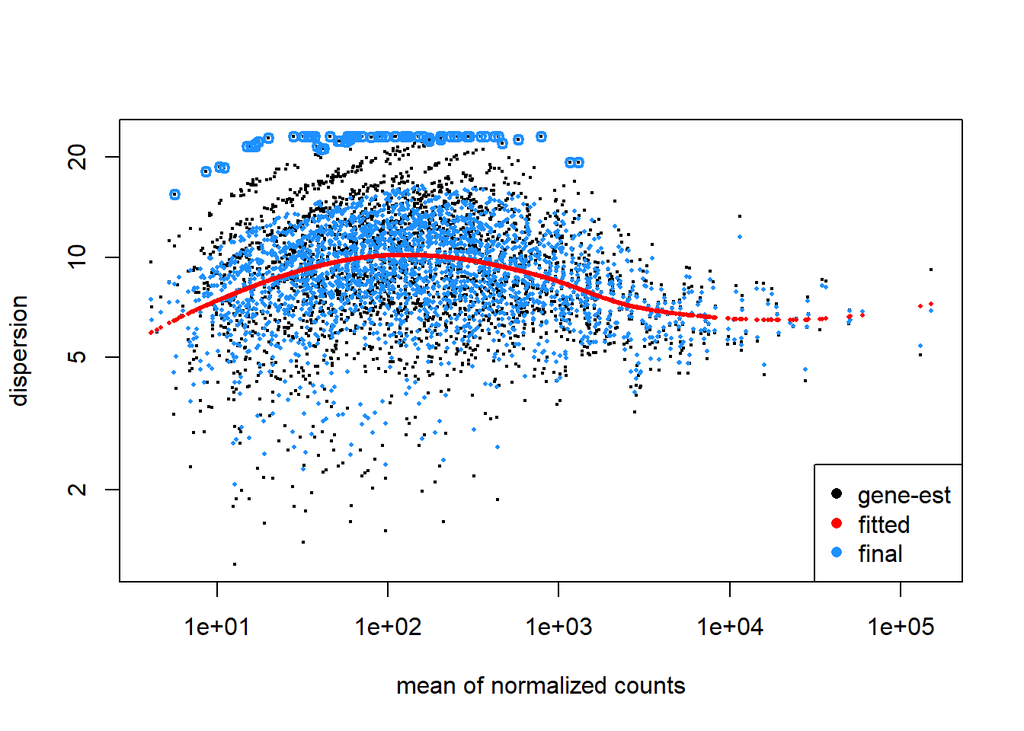

```r
ps_ds <- phyloseq::phyloseq_to_deseq2(ps_gp_bact, ~1)
ps_ds = DESeq2::estimateSizeFactors(ps_ds)
ps_ds = DESeq2::estimateDispersions(ps_ds, fitType = "parametric")
DESeq2::plotDispEsts(ps_ds)
```

```r
# make a copy of the ps object with vst-transformed otu_table
ps_vst <- ps_gp_bact
vst<-DESeq2::getVarianceStabilizedData(ps_ds)
phyloseq::otu_table(ps_vst) <- phyloseq::otu_table(vst, taxa_are_rows = TRUE)
ps_vst
```

```
## phyloseq-class experiment-level object
## otu_table()   OTU Table:         [ 2640 taxa and 23 samples ]
## sample_data() Sample Data:       [ 23 samples by 9 sample variables ]
## tax_table()   Taxonomy Table:    [ 2640 taxa by 7 taxonomic ranks ]
## phy_tree()    Phylogenetic Tree: [ 2640 tips and 2639 internal nodes ]
```

# ORDINATIONS

We’ll run two examples of ordinations on vst-transformed data:

- NMDS in phyloseq
- NMDS in vegan with environmental data

## Check available distances/dissimilarity metrics

```r
help(distanceMethodList, package="phyloseq")
help(betadiver, package="vegan")
help(vegdist, package="vegan")
help(decostand, package = "vegan")
```

## Non-metric Multidimensional Scaling (NMDS)

**For Bray-Curtis distances, all values in otu table must be positive**

```r
min(otu_table(ps_vst))
```

```
## [1] -2.222172
```

```r
ps_vst_pos <- transform_sample_counts(ps_vst, function(x) x+2.23)
```

### NMDS with Bray-Curtis distances in phyloseq::ordinate

See manual https://bioconductor.org/packages/devel/bioc/manuals/phyloseq/man/phyloseq.pdf  
`phyloseq` does not allow `envfit` and no specifications can be adjusted, but easy to explore samples/species data  
Available methods include: DCA, CCA, RDA, CAP, DPCoA, NMDS, MDS/PCoA

**Run NMDS with phyloseq::ordinate**

```r
# specify file, method, distance, and iterations
# default is 20 iterations, can increase trymax to get convergence
ord1 <- phyloseq::ordinate(ps_vst_pos, "NMDS", "bray", trymax=100)
```

```
## Wisconsin double standardization
## *** Solution reached
```

```r
ord1
```

```
##
## Call:
## metaMDS(comm = veganifyOTU(physeq), distance = distance, trymax = 100)
##
## global Multidimensional Scaling using monoMDS
##
## Data:     wisconsin(veganifyOTU(physeq))
## Distance: bray
##
## Dimensions: 2
## Stress:     0.1200766
## Stress type 1, weak ties
## Two convergent solutions found after 20 tries
## Scaling: centring, PC rotation, halfchange scaling
## Species: expanded scores based on 'wisconsin(veganifyOTU(physeq))'
```

**Evaluate NMDS run with stress**

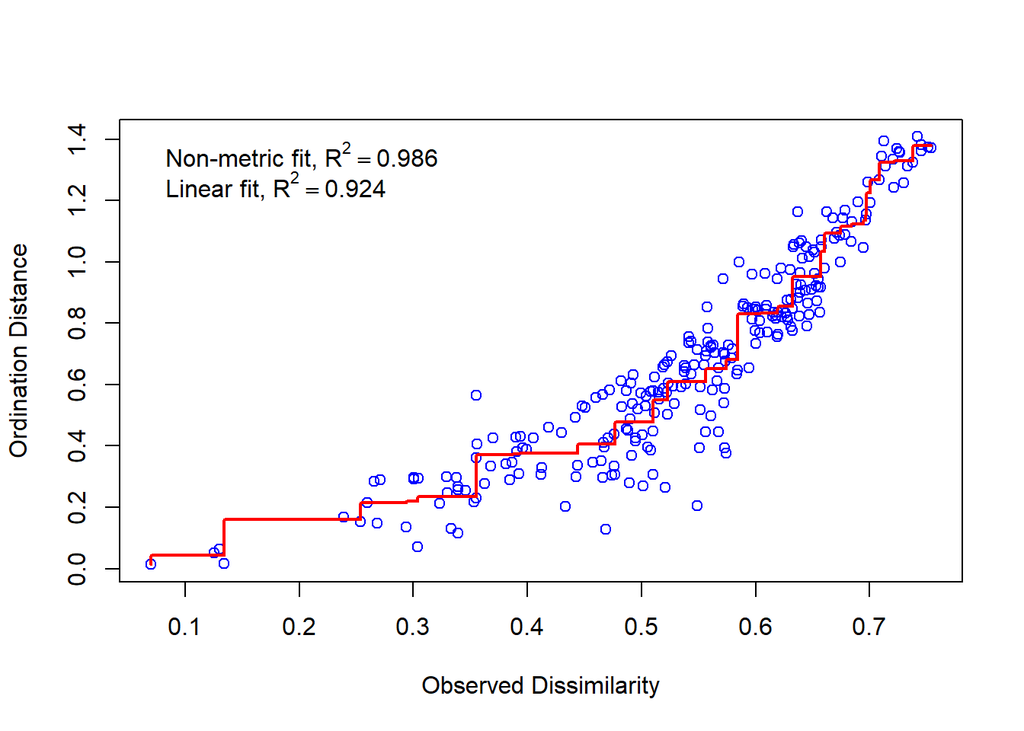

```r
# shows relationship between actual dissimilarities and ordination distances
# if highly correlated, stress is low and ordination is a good representation of data
# if poorly correlated (large scatter), ordination is not representative of original distances
vegan::stressplot(ord1)
```

**Basic ordination plot by samples**

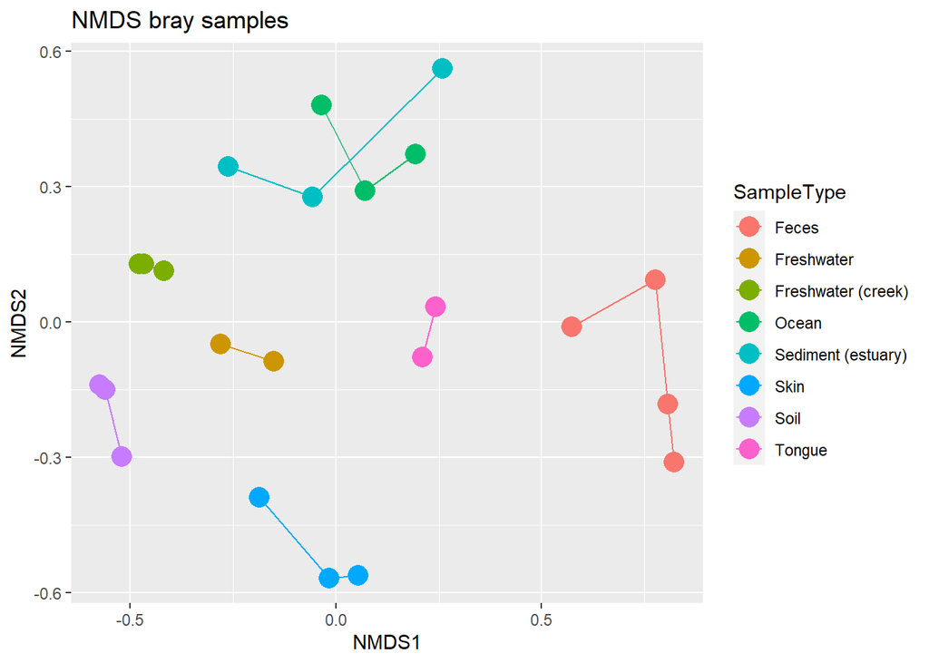

```r
phyloseq::plot_ordination(ps_vst_pos, ord1,
                          type="samples",
                          color="SampleType",
                          title="NMDS bray samples") +
                          ggplot2::geom_line() +
                          ggplot2::geom_point(size=5)
```

```r
# If you want to draw confidence ellipses around the treatments
# add the following to the plot_ordination code above:
#    + ggplot2::stat_ellipse(type="norm", linetype = 2)
# not done here because not enough replicate points for calculation
```

**Biplot of samples + taxa**

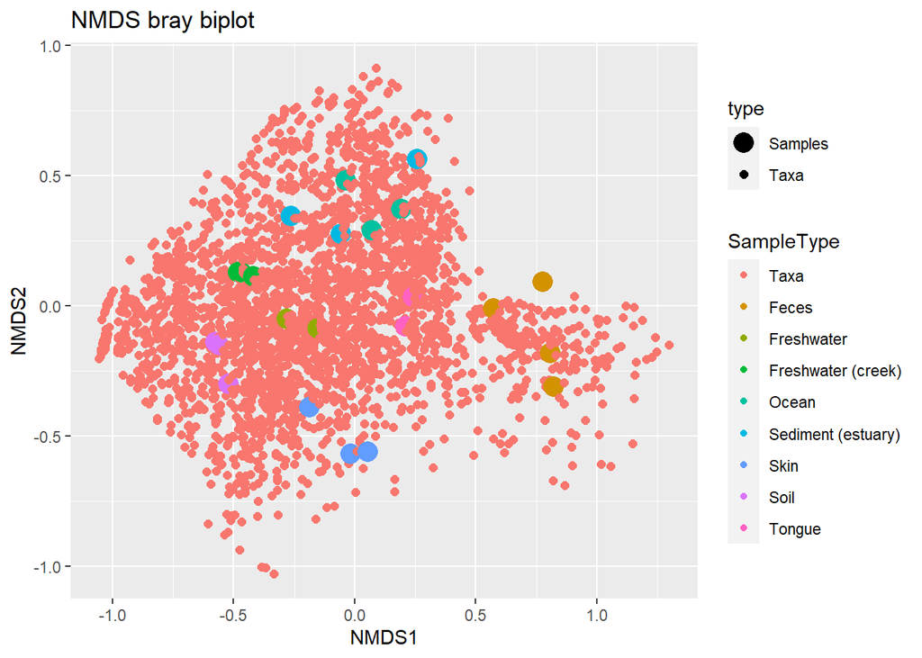

```r
phyloseq::plot_ordination(ps_vst_pos, ord1,
                      type="biplot",
                      color="SampleType",
                      title = "NMDS bray biplot")
```

**Split plot for samples and taxa**

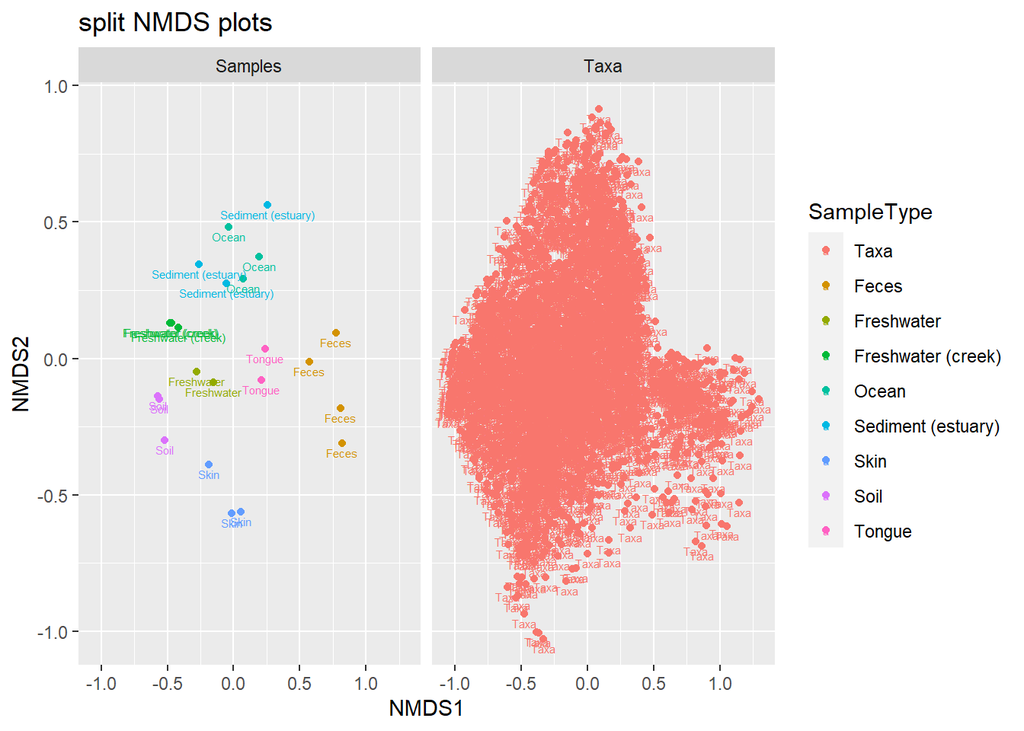

```r
phyloseq::plot_ordination(ps_vst_pos, ord1,
                      type="split", color="SampleType",
                      label="SampleType",
                      title="split NMDS plots")
```

**Extract NMDS data for further analysis or export**

```r
# two ways to download the data for further analyses or graphics
# export just the sample names + xy coordinates
write.csv(ord1$points, "wk6_NMDS_sample_xy.csv")
write.csv(ord1$species, "wk6_NMDS_species_xy.csv")
# alternatively export sample names, xy coordinates, and sample data
nmds.bray.xy <- plot_ordination(ps_vst_pos, ord1, justDF = TRUE)
write.csv(nmds.bray.xy, "Wk6_NMDS_xy.csv")
```

### NMDS with Bray-Curtis distances + environmental data in vegan::metaMDS

see vegan manual https://cran.r-project.org/web/packages/vegan/vegan.pdf

**Prepare otu_table for vegan**

```r
# make sure otu file has samples as rows and ASVs as columns; transpose if needed
# add constant to remove negative values
# alternatively, could access the otu_table slot in ps_vst_pos
otu_vst<- t(vst)
min(otu_vst)
```

```
## [1] -2.222172
```

```r
otu_vst <- otu_vst+2.23
```

**Run NMDS with vegan::metaMDS**  
https://www.rdocumentation.org/packages/vegan/versions/2.4-2/topics/metaMDS

```r
# specify community file, distance, and autotransform = FALSE to avoid automated vegan transformations
ord2 <- vegan::metaMDS(otu_vst, distance = "bray", autotransform = FALSE, trymax=20)
```

```
## *** Solution reached
```

```r
ord2
```

```
##
## Call:
## vegan::metaMDS(comm = otu_vst, distance = "bray", trymax = 20,      autotransform = FALSE)
##
## global Multidimensional Scaling using monoMDS
##
## Data:     otu_vst
## Distance: bray
##
## Dimensions: 2
## Stress:     0.1327717
## Stress type 1, weak ties
## Two convergent solutions found after 20 tries
## Scaling: centring, PC rotation, halfchange scaling
## Species: expanded scores based on 'otu_vst'
```

```r
# what to do if you don't have convergence?
# extend number of random starts by specifying "trymax" > default = 20
# start a new ordination using the previous run as the start with "previous.best" to avoid local optima
# increase max iterations with "maxit"
# consider a different data transformation
```

**Evaluate ordination fit with stress**

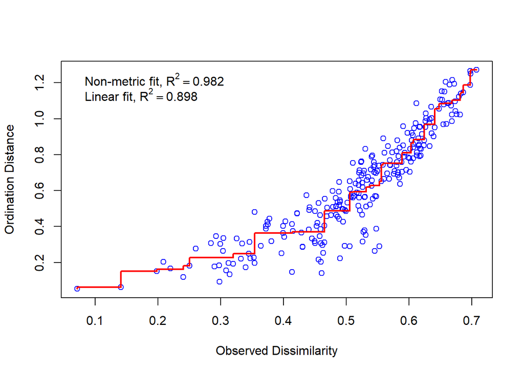

```r
vegan::stressplot(ord2)
```

**Evaluate environmental correlations to NMDS with vegan::envfit**  
https://www.rdocumentation.org/packages/vegan/versions/2.4-2/topics/envfit

```r
# using the sam.new file because it is limited to the quantitative vars
# alternatively could specify the variables in the file to use
# note that this acts on ord object, not original otu file
ord2_env <- vegan::envfit(ord2, sam.new, permutations = 99, strata = NULL, choices=c(1,2))
ord2_env
```

```
##
## ***VECTORS
##
##             NMDS1    NMDS2     r2 Pr(>r)
## pH       -0.15554  0.98783 0.4913   0.01 **
## salinity  0.47522 -0.87987 0.1070   0.32
## ---
## Signif. codes:  0 '***' 0.001 '**' 0.01 '*' 0.05 '.' 0.1 ' ' 1
## Permutation: free
## Number of permutations: 99
```

**Plot with confidence ellipses around treatments**  
https://rdrr.io/github/jfq3/ggordiplots/man/gg_ordiplot.html

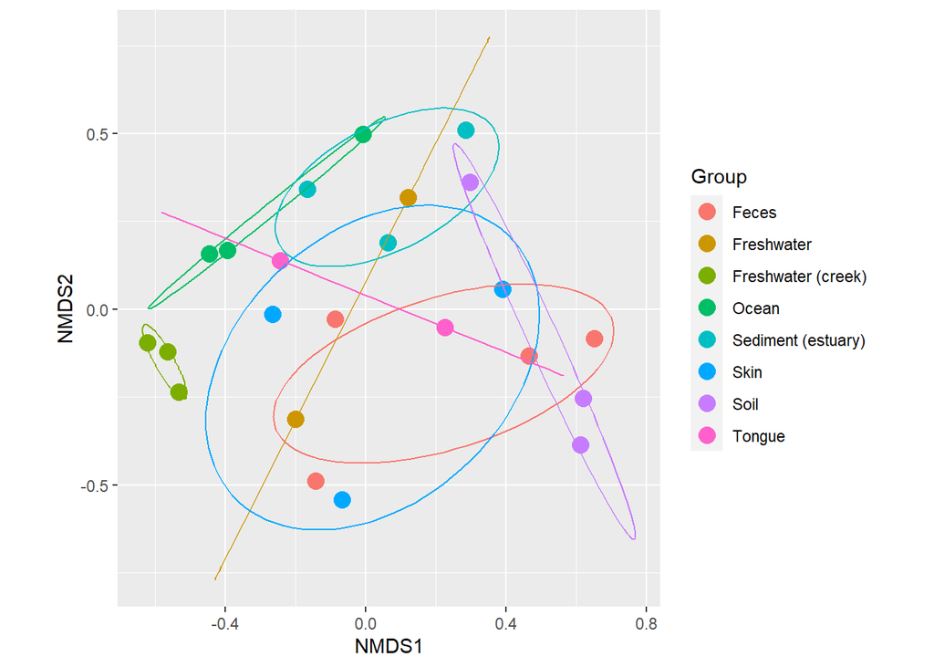

```r
# groups = defines the point groupings based on column in sample data file
# choice = axes to plot
# kind = "sd", "se", or "ehull"
  # sd = standard deviation of points
  # se = standard deviations of averages
  # ehull = ellipsoid hull, minimum boundary around the points
# conf = confidence limits for ellipses, multiplies sd or se by appropriate value
ggordiplots::gg_ordiplot(ord2, groups=sam.all$SampleType, choices = c(1,2), kind = "se", conf = 0.95, pt.size=4)
```

**Plot with vectors of environmental variables to the ordination plot**  
https://rdrr.io/github/jfq3/ggordiplots/man/gg_envfit.html

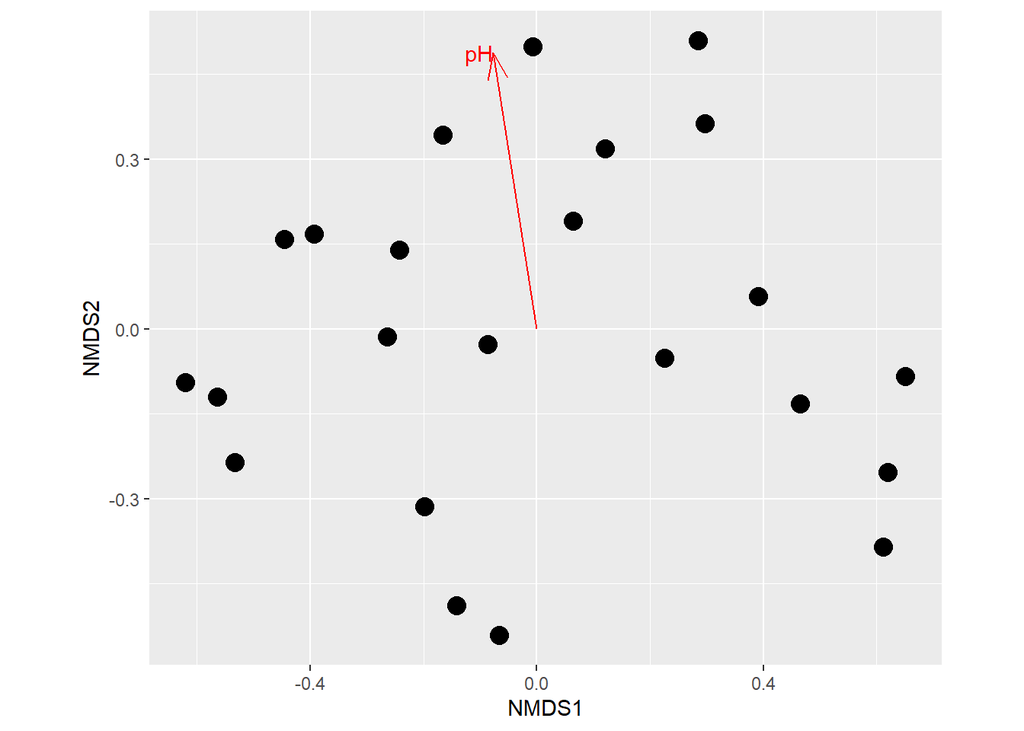

```r
# alpha controls what vectors show up based on sig
ggordiplots::gg_envfit(ord=ord2, env=sam.new, perm=99, pt.size=4, alpha= 0.05)
```

**Create contour plots for important environmental factors**  
https://rdrr.io/github/jfq3/ggordiplots/man/gg_ordisurf.html

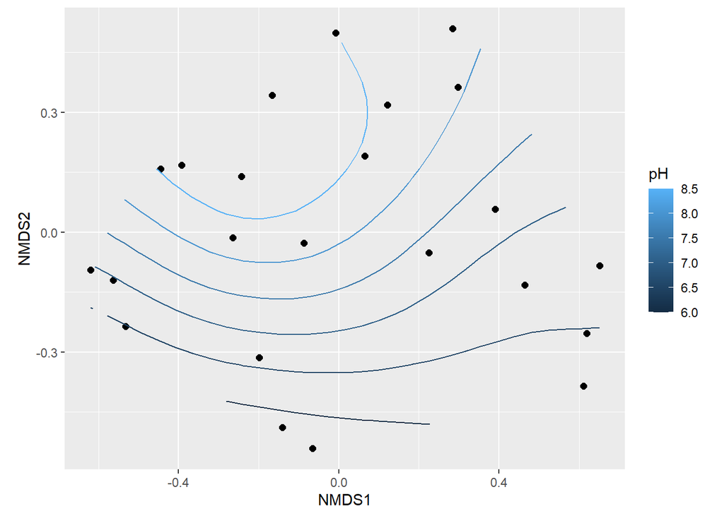

```r
# define the countours using env.var to select a continuous variable from the sample data file
# change bin width to adjust size of contours
ggordiplots::gg_ordisurf(ord=ord2, env.var=sam.new$pH, choices = c(1,2), binwidth=0.5, pt.size=2, var.label="pH")
```

**Extract the data for use elsewhere as needed**

```r
sampleScores <- ord2$points
otuScores <- ord2$species
envScores <- vegan::scores(ord2_env, "vectors")
envCorrels <- data.frame(r=ord2_env$vectors$r, p=ord2_env$vectors$pvals)
```